# Kapitel 9 - Klassen und Objekte

Modernes Programmieren ist zumeist objektorientiert. Das heißt der Fokus liegt nicht so sehr auf fest vorgelegten Abläufen und Rechenoperationen, die abgearbeitet werden, sondern auf Objekten, die definiert werden, Eigenschaften und Fähigkeit haben und sehr vielseitig benutzt werden können.

Auch in Python kann man sehr leicht eigene **Objekte** erstellen. Ein Objekt gehört immer einer **Klasse** an, die man auch selbst definieren kann.

Im Folgenden werden wir Objekte und Klassen nutzen um ein Verkehrssystem zu simulieren.

Dieses Verkehrssystem wird sehr rudimentär sein. Es wird Personen geben, die einen Heimatort und einen Arbeitsort besitzen, und zwischen diesen Orten hin- und herpendeln. Eine Person wird immer ein Objekt einer Klasse sein und Eigenschaften (z.B. Heimatort) und Fähigkeiten - beim Programmieren eher **Methoden** genannt - (z.b. zur Arbeit fahren) haben.

Wir erstellen nun also die Klasse `Person` und legen die Initialisierungsmethode fest. Dort bekommen die Personen eine zufällige Heimatadresse. **Methoden werden ähnlich definiert wie Functions**, der einzige Unterschied ist, dass Methoden als erste Inputvariable immer `self` haben, also sich selbst. Immer wenn also eine Methode aufgerufen wird, wird automatisch übergeben, welches Objekt dieser Klasse (also für uns welche Person) die Methode aufgerufen hat.

```python
import matplotlib.pyplot as plt
import random


class Person:
    def __init__(self):
        #eine neue Person wird initialisiert

        #sie bekommt eine zufällig Heimadresse
        self.home = [random.randint(0,10),random.randint(0,10)]
```

Wie beim Definieren von Funktion, macht das Definieren von Klassen an sich noch nichts. Sie müssen immer erst im Hauptprogramm aufgerufen werden. Erstellen wir nun zur Probe eine Person und zeichen wir ihre Heimatadresse als Scatterplot.

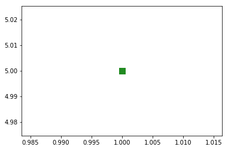

```python
import matplotlib.pyplot as plt
import random


class Person:
    def __init__(self):
        #eine neue Person wird initialisiert

        #sie bekommt eine zufällig Heimadresse
        self.home = [random.randint(0,10),random.randint(0,10)]


#----Hier startet das Hauptprogramm----


#wir erstellen ein Objekt der Klasse person mit dem Namen person1
person1 = Person()
#Dann zeichnen wir den Heimatort von person1
#s ist die Größe des Markers, die Form "s" steht für square
plt.scatter(person1.home[0],person1.home[1], s = 100, marker = "s", c = "forestgreen")
plt.show()
```

Wir haben nun erfolgreich ein Objekt der Klasse `Person` erstellt und die Heimatadresse gezeichnet. Eleganter wäre das aber, wenn wir das Zeichnen nicht im Hauptprogramm machen, sondern es als **Methode** erstellen: Alle Personen sollen die Fähigkeit erhalten sich selbst zu zeichnen. Wir nennen diese Methode `zeichnen` und definieren sie direkt nach `__init__`. Immer wenn wir diese Methode dann aufrufen möchten schreiben wir `NameDerPerson.zeichnen()`.

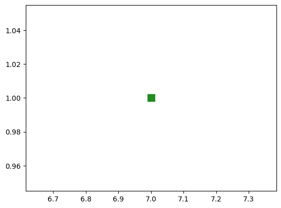

```python
import matplotlib.pyplot as plt
import random


class Person:
    def __init__(self):
        #eine neue Person wird initialisiert

        #sie bekommt eine zufällig Heimadresse
        self.home = [random.randint(0,10),random.randint(0,10)]

    def zeichnen(self):
        #Die Personen zeichnen ihre Heimatadresse
        #s ist die Größe des Markers, die Form "s" steht für square
        plt.scatter(self.home[0],self.home[1], s = 100, marker = "s", c = "forestgreen")


#----Hier startet das Hauptprogramm----

#wir erstellen ein Objekt der Klasse person mit dem Namen person1
person1 = Person()
#Dann zeichnen wir den Heimatort von person1
person1.zeichnen()
plt.show()
```

Mit dieser eleganten Lösung können wir nun auch **mehrere Objekte** der gleichen Klasse einfach erstellen und verwalten. Wir erstellen eine leere Liste und fügen dann 20 Objekte der Klasse `Person` hinzu. In einer Schleife rufen wir sie dann alle auf und lassen sie zeichnen.

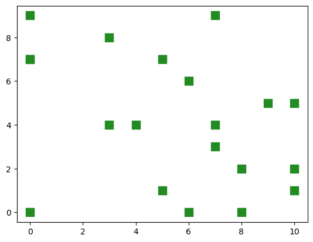

```python
import matplotlib.pyplot as plt
import random


class Person:
    def __init__(self):
        #eine neue Person wird initialisiert

        #sie bekommt eine zufällig Heimadresse
        self.home = [random.randint(0,10),random.randint(0,10)]

    def zeichnen(self):
        #Die Personen zeichnen ihre Heimatadresse
        #s ist die Größe des Markers, die Form "s" steht für square
        plt.scatter(self.home[0],self.home[1], s = 100, marker = "s", c = "forestgreen")


#----Hier startet das Hauptprogramm----

#Wir erstellen eine leere Liste
allepersonen=[]

#Wir fügen neue Personen
for it in range(20):
    allepersonen.append(Person())

for it in range(20):
    allepersonen[it].zeichnen()
plt.show()
```

Die letzte Schleife läuft hierbei über eine Liste von Objekten und ruft im it-ten Schritt das it-te Objekt auf um etwas damit zu machen. Diese Struktur ist so häufig, dass es in Python dafür eine **Kurzschreibweise** gibt. Statt

`for it in range(20):`

$\ \ \ \ \ \ $`Befehl für Objekt das unter listenname[it] gespeichert ist`

kann man verkürz schreiben

`for obj in listenname:`

$\ \ \ \ \ \ $`Befehl für obj`

, wobei `obj` eine frei wählbare Bezeichnung ist.

Für unser Programm wäre diese Kurzschreibweise also:

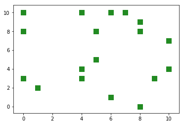

```python
import matplotlib.pyplot as plt
import random


class Person:
    def __init__(self):
        #eine neue Person wird initialisiert

        #sie bekommt eine zufällig Heimadresse
        self.home = [random.randint(0,10),random.randint(0,10)]

    def zeichnen(self):
        #Die Personen zeichnen ihre Heimatadresse
        #s ist die Größe des Markers, die Form "s" steht für square
        plt.scatter(self.home[0],self.home[1], s = 100, marker = "s", c = "forestgreen")


#----Hier startet das Hauptprogramm----

#Wir erstellen eine leere Liste
allepersonen=[]

#Wir fügen neue Personen
for it in range(20):
    allepersonen.append(Person())

for p in allepersonen:
    p.zeichnen()

plt.show()
```

Zusätzlich zu einer Heimatadresse bekommen alle Personen nun auch einen **Arbeitsort**. In unserem Modell gibt es 3 Arbeitsorte, die unterschiedlich groß sind. Ein Arbeitsort befindet sich auf Position [7,9], einer auf [4,1] und einer auf [5,5].

Beim Intitialisieren bekommen alle Personen also auch einen Arbeitsort aus einer Liste der Arbeitsorte zugewiesen. Da nicht alle Arbeitsorte gleich oft besucht werden, kommen auch nicht alle Orte gleich oft in der Liste vor.

Auch in der Methode `zeichnen` nehmen wir eine Änderung vor: Auch der Arbeitsplatz soll gezeichnet werden.

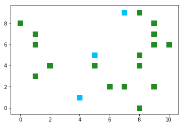

```python
import matplotlib.pyplot as plt
import random


class Person:
    def __init__(self):
        #eine neue Person wird initialisiert

        #sie bekommt eine zufällig Heimadresse
        self.home = [random.randint(0,10),random.randint(0,10)]
        #und eine Arbeitsadresse aus einer Liste
        self.work = random.choice([[5,5],[5,5],[5,5],[4,1],[4,1],[7,9]])

    def zeichnen(self):
        #Die Personen zeichnen ihre Heimatadresse
        #s ist die Größe des Markers, die Form "s" steht für square
        plt.scatter(self.home[0],self.home[1], s = 100, marker = "s", c = "forestgreen")
        #Und ihren Arbeitsort
        plt.scatter(self.work[0],self.work[1], s = 100, marker = "s", c = "deepskyblue")


#----Hier startet das Hauptprogramm----

#Wir erstellen eine leere Liste
allepersonen=[]

#Wir fügen neue Personen
for it in range(20):
    allepersonen.append(Person())

for p in allepersonen:
    p.zeichnen()

plt.show()
```

Nun möchten wir noch eine wichtige Methode in unser Verkehrssystem einbauen. Personen sollen die Fähigkeit bekommen von ihrem **Heimatort zum Arbeitsort zu fahren**. Damit sehen wir dann, welche Straßen der Modellstadt häufig benutzt werden und welche nicht so häufig.

Für das Fahren benutzen wir die sogenannte **Manhattan-Metrik**: In dieser Metrik ist es nur erlaubt entlang der x-Achse und entlang der y-Achse zu fahren, nicht aber diagonal. Unsere Personen fahren also zuerst in x-Richtung bei konstantem y, dann in y-Richtung bei konstantem x.

Das Fahren selbst implementieren wir einfach als Linienplots zusätzlich zu unserem bisherigen Plot.

Erstellen wir nun die Methode `fahren` und rufen wir sie für alle Personen auf.

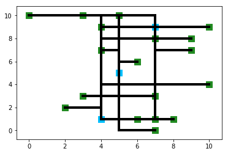

```python
import matplotlib.pyplot as plt
import random


class Person:
    def __init__(self):
        #eine neue Person wird initialisiert

        #sie bekommt eine zufällig Heimadresse
        self.home = [random.randint(0,10),random.randint(0,10)]
        #und eine Arbeitsadresse aus einer Liste
        self.work = random.choice([[5,5],[5,5],[5,5],[4,1],[4,1],[7,9]])

    def zeichnen(self):
        #Die Personen zeichnen ihre Heimatadresse
        #s ist die Größe des Markers, die Form "s" steht für square
        plt.scatter(self.home[0],self.home[1], s = 100, marker = "s", c = "forestgreen")
        #Und ihren Arbeitsort
        plt.scatter(self.work[0],self.work[1], s = 100, marker = "s", c = "deepskyblue")

    def fahren(self):
        #Wir zeichnen zwei Linien:
        #Linie 1 geht in der x-Richtung von home nach work, y bleibt konstant bei home
        #Linie 2 geht in y-Richtung von home nach work, x bleibt konstant bei work
        plt.plot([self.home[0],self.work[0]],[self.home[1],self.home[1]],c = "black", lw = 4)
        plt.plot([self.work[0],self.work[0]],[self.home[1],self.work[1]],c = "black", lw = 4)


#----Hier startet das Hauptprogramm----

#Wir erstellen eine leere Liste
allepersonen=[]

#Wir fügen neue Personen
for it in range(20):
    allepersonen.append(Person())

for p in allepersonen:
    p.zeichnen()
    p.fahren()

plt.show()
```

Nun sehen wir welche Strecken benutzt werden, aber nicht unbedingt welche wie oft benutzt wird, da wir oft Linien übereinderzeichnen und der Plot keine Auskunft darüber gibt, wie viele Linien übereinander gezeichnet wurden.

Dieses Problem können wir mit dem Attribut `alpha` lösen. Das `alpha` einer Linie sagt uns die **Deckkraft**. Der Wert 0.1 sagt, dass nur 10 Prozent Deckkraft benutzt werden, also erst wenn wir 10 Linien übereinander zeichnen, sieht die Linie wirklich schwarz aus, sonst sieht man Teile des weißen Hintergrunds durchschimmern. Damit sollten wir mehr über unser Verkehrssystem lernen können.

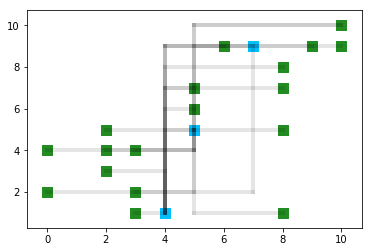

```python
import matplotlib.pyplot as plt
import random


class Person:
    def __init__(self):
        #eine neue Person wird initialisiert

        #sie bekommt eine zufällig Heimadresse
        self.home = [random.randint(0,10),random.randint(0,10)]
        #und eine Arbeitsadresse aus einer Liste
        self.work = random.choice([[5,5],[5,5],[5,5],[4,1],[4,1],[7,9]])

    def zeichnen(self):
        #Die Personen zeichnen ihre Heimatadresse
        #s ist die Größe des Markers, die Form "s" steht für square
        plt.scatter(self.home[0],self.home[1], s = 100, marker = "s", c = "forestgreen")
        #Und ihren Arbeitsort
        plt.scatter(self.work[0],self.work[1], s = 100, marker = "s", c = "deepskyblue")

    def fahren(self):
        #Wir zeichnen zwei Linien:
        #Linie 1 geht in der x-Richtung von home nach work, y bleibt konstant bei home
        #Linie 2 geht in y-Richtung von home nach work, x bleibt konstant bei work
        plt.plot([self.home[0],self.work[0]],[self.home[1],self.home[1]],c = "black", alpha = 0.1, lw = 4)
        plt.plot([self.work[0],self.work[0]],[self.home[1],self.work[1]],c = "black", alpha = 0.1, lw = 4)


#----Hier startet das Hauptprogramm----

#Wir erstellen eine leere Liste
allepersonen=[]

#Wir fügen neue Personen
for it in range(20):
    allepersonen.append(Person())

for p in allepersonen:
    p.zeichnen()
    p.fahren()

plt.show()
```

Noch mehr Informationen über das Verkehrssystem würden wir erhalten, wenn wir die zurückgelegte **Gesamtstrecke** berechnen würden. Dazu werden wir in einem ersten Schritt eine Methode einbauen, die zu jeder Person die Länge des Arbeitsweges ausgibt.

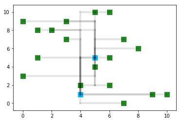

```python
import matplotlib.pyplot as plt
import random


class Person:
    def __init__(self):
        #eine neue Person wird initialisiert

        #sie bekommt eine zufällig Heimadresse
        self.home = [random.randint(0,10),random.randint(0,10)]
        #und eine Arbeitsadresse aus einer Liste
        self.work = random.choice([[5,5],[5,5],[5,5],[4,1],[4,1],[7,9]])

    def zeichnen(self):
        #Die Personen zeichnen ihre Heimatadresse
        #s ist die Größe des Markers, die Form "s" steht für square
        plt.scatter(self.home[0],self.home[1], s = 100, marker = "s", c = "forestgreen")
        #Und ihren Arbeitsort
        plt.scatter(self.work[0],self.work[1], s = 100, marker = "s", c = "deepskyblue")

    def fahren(self):
        #Wir zeichnen zwei Linien:
        #Linie 1 geht in der x-Richtung von home nach work, y bleibt konstant bei home
        #Linie 2 geht in y-Richtung von home nach work, x bleibt konstant bei work
        plt.plot([self.home[0],self.work[0]],[self.home[1],self.home[1]],c = "black", alpha = 0.1, lw = 4)
        plt.plot([self.work[0],self.work[0]],[self.home[1],self.work[1]],c = "black", alpha = 0.1, lw = 4)

    def arbeitsweg(self):
        #der Weg errechnet sieh hier aus dem Abstand in x-Richtung + dem Abstand in y-Richtung
        dist = abs(self.home[0]-self.work[0]) + abs(self.home[1]-self.work[1])
        return dist


#----Hier startet das Hauptprogramm----

#Wir erstellen eine leere Liste
allepersonen=[]

#Wir fügen neue Personen
for it in range(20):
    allepersonen.append(Person())

for p in allepersonen:
    p.zeichnen()
    p.fahren()

plt.show()
```

Nun schreiben wir noch eine Function, die uns **alle Strecken aufsummiert** und die Summe auf den Bildschirm ausgibt. Achtung: Diese Function ist **keine Methode der Klasse**, denn eine einzelne Person kann nicht über die Strecken aller anderen Personen bescheidwissen. Deswegen ist die Defintion dieser Funktion nicht eingerückt, also nicht teil der Klasse:

```
Gesamtstrecke:
116
```

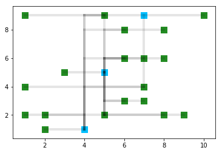

```python
import matplotlib.pyplot as plt
import random


class Person:
    def __init__(self):
        #eine neue Person wird initialisiert

        #sie bekommt eine zufällig Heimadresse
        self.home = [random.randint(0,10),random.randint(0,10)]
        #und eine Arbeitsadresse aus einer Liste
        self.work = random.choice([[5,5],[5,5],[5,5],[4,1],[4,1],[7,9]])

    def zeichnen(self):
        #Die Personen zeichnen ihre Heimatadresse
        #s ist die Größe des Markers, die Form "s" steht für square
        plt.scatter(self.home[0],self.home[1], s = 100, marker = "s", c = "forestgreen")
        #Und ihren Arbeitsort
        plt.scatter(self.work[0],self.work[1], s = 100, marker = "s", c = "deepskyblue")

    def fahren(self):
        #Wir zeichnen zwei Linien:
        #Linie 1 geht in der x-Richtung von home nach work, y bleibt konstant bei home
        #Linie 2 geht in y-Richtung von home nach work, x bleibt konstant bei work
        plt.plot([self.home[0],self.work[0]],[self.home[1],self.home[1]],c = "black", alpha = 0.1, lw = 4)
        plt.plot([self.work[0],self.work[0]],[self.home[1],self.work[1]],c = "black", alpha = 0.1, lw = 4)

    def arbeitsweg(self):
        #der Weg errechnet sieh hier aus dem Abstand in x-Richtung + dem Abstand in y-Richtung
        dist = abs(self.home[0]-self.work[0]) + abs(self.home[1]-self.work[1])
        return dist

def gesamtstrecke():
    #wir berechnen die Gesamtstrecke
    gesamt = 0
    #Wir gehen in einer Schleife über alle Personen
    for p in allepersonen:
        #und summieren die Arbeitswege
        gesamt = gesamt + p.arbeitsweg()

    print("Gesamtstrecke:")
    print(gesamt)

#----Hier startet das Hauptprogramm----

#Wir erstellen eine leere Liste
allepersonen=[]

#Wir fügen neue Personen
for it in range(20):
    allepersonen.append(Person())

for p in allepersonen:
    p.zeichnen()
    p.fahren()

gesamtstrecke()
plt.show()
```

Die Position von `plt.show()` entscheidet, ob der Plot vor oder nach dem Print-Text angezeigt wird.

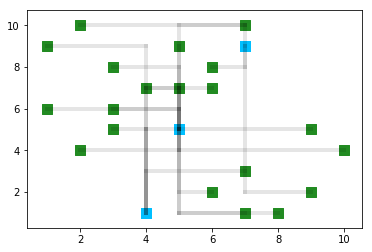

```
Gesamtstrecke:
111
```

```python
import matplotlib.pyplot as plt
import random


class Person:
    def __init__(self):
        #eine neue Person wird initialisiert

        #sie bekommt eine zufällig Heimadresse
        self.home = [random.randint(0,10),random.randint(0,10)]
        #und eine Arbeitsadresse aus einer Liste
        self.work = random.choice([[5,5],[5,5],[5,5],[4,1],[4,1],[7,9]])

    def zeichnen(self):
        #Die Personen zeichnen ihre Heimatadresse
        #s ist die Größe des Markers, die Form "s" steht für square
        plt.scatter(self.home[0],self.home[1], s = 100, marker = "s", c = "forestgreen")
        #Und ihren Arbeitsort
        plt.scatter(self.work[0],self.work[1], s = 100, marker = "s", c = "deepskyblue")

    def fahren(self):
        #Wir zeichnen zwei Linien:
        #Linie 1 geht in der x-Richtung von home nach work, y bleibt konstant bei home
        #Linie 2 geht in y-Richtung von home nach work, x bleibt konstant bei work
        plt.plot([self.home[0],self.work[0]],[self.home[1],self.home[1]],c = "black", alpha = 0.1, lw = 4)
        plt.plot([self.work[0],self.work[0]],[self.home[1],self.work[1]],c = "black", alpha = 0.1, lw = 4)

    def arbeitsweg(self):
        #der Weg errechnet sieh hier aus dem Abstand in x-Richtung + dem Abstand in y-Richtung
        dist = abs(self.home[0]-self.work[0]) + abs(self.home[1]-self.work[1])
        return dist

def gesamtstrecke():
    #wir berechnen die Gesamtstrecke
    gesamt = 0
    #Wir gehen in einer Schleife über alle Personen
    for p in allepersonen:
        #und summieren die Arbeitswege
        gesamt = gesamt + p.arbeitsweg()

    print("Gesamtstrecke:")
    print(gesamt)

#----Hier startet das Hauptprogramm----

#Wir erstellen eine leere Liste
allepersonen=[]

#Wir fügen neue Personen
for it in range(20):
    allepersonen.append(Person())

for p in allepersonen:
    p.zeichnen()
    p.fahren()

plt.show()

gesamtstrecke()
```

Nun möchten wir versuchen, ob wir diesen Verkehrssystem noch ein wenig **optimieren** können. Viele Personen leben weit weg von ihrem Arbeitsort und könnten sich durch Umziehen viel Strecke sparen. Schreiben wir also eine Methode, die den **Heimatort einer Person probeweise ändert**. Sollte sich der Arbeitsweg dadurch verlängert haben, wird die Änderung wieder rückgängig gemacht.

Diese Methode sollte aus 3 Teilen bestehen: Zuerst merken wir uns die aktuelle Strecke und Heimatadresse. Dann ändern wir die Heimatadresse auf einen neuen zufälligen Wert. Im letzten Schritt wird die Änderung rückgängig gemacht, wenn sie unvorteilhaft war (dafür benötigen wir die Informationen über alte Strecke und Heimatadresse).

Wir definieren diese Methode und geben unseren Personen dann 10 mal die Chance umzuziehen. Danach wiederholen wir den Plot und die Streckenberechnung, um zu sehen welchen Effekt diese Änderung hatte.

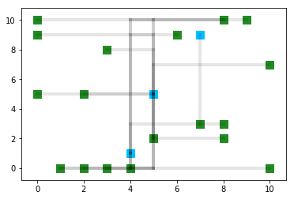

```
Gesamtstrecke:
141
```

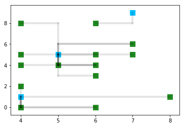

```
Gesamtstrecke:
42
```

```python
import matplotlib.pyplot as plt
import random


class Person:
    def __init__(self):
        #eine neue Person wird initialisiert

        #sie bekommt eine zufällig Heimadresse
        self.home = [random.randint(0,10),random.randint(0,10)]
        #und eine Arbeitsadresse aus einer Liste
        self.work = random.choice([[5,5],[5,5],[5,5],[4,1],[4,1],[7,9]])

    def zeichnen(self):
        #Die Personen zeichnen ihre Heimatadresse
        #s ist die Größe des Markers, die Form "s" steht für square
        plt.scatter(self.home[0],self.home[1], s = 100, marker = "s", c = "forestgreen")
        #Und ihren Arbeitsort
        plt.scatter(self.work[0],self.work[1], s = 100, marker = "s", c = "deepskyblue")

    def fahren(self):
        #Wir zeichnen zwei Linien:
        #Linie 1 geht in der x-Richtung von home nach work, y bleibt konstant bei home
        #Linie 2 geht in y-Richtung von home nach work, x bleibt konstant bei work
        plt.plot([self.home[0],self.work[0]],[self.home[1],self.home[1]],c = "black", alpha = 0.1, lw = 4)
        plt.plot([self.work[0],self.work[0]],[self.home[1],self.work[1]],c = "black", alpha = 0.1, lw = 4)

    def arbeitsweg(self):
        #der Weg errechnet sieh hier aus dem Abstand in x-Richtung + dem Abstand in y-Richtung
        dist = abs(self.home[0]-self.work[0]) + abs(self.home[1]-self.work[1])
        return dist

    def umziehen(self):
        #Methode um den Heimatort zu wechseln

        #wir speichern den aktuellen Weg und den aktuellen Heimatort
        alterweg = self.arbeitsweg()
        oldhome = self.home

        #die Person zieht auf ein zufällige Position um
        self.home = [random.randint(0,10),random.randint(0,10)]

        #Wenn der Weg dadurch länger geworden ist...
        if self.arbeitsweg() > alterweg:
            #... wird die Änderung rückgängig gemacht
            self.home = oldhome


def gesamtstrecke():
    #wir berechnen die Gesamtstrecke
    gesamt = 0
    #Wir gehen in einer Schleife über alle Personen
    for p in allepersonen:
        #und summieren die Arbeitswege
        gesamt = gesamt + p.arbeitsweg()

    print("Gesamtstrecke:")
    print(gesamt)


#----hier beginnt das eigentliche Programm----


#Wir erstellen eine leere Liste
allepersonen=[]

#Wir fügen neue Personen
for it in range(20):
    allepersonen.append(Person())

#Wir iterieren über alle Personen
for p in allepersonen:
    #Jede Person benutzt die Methode zeichnen und fahren
    p.zeichnen()
    p.fahren()

#Der Plot wird angezeigt
plt.show()
#Die Gesamtstrecke wird berechnet
gesamtstrecke()

#Wir lassen die Personen umziehen
for it in range(10):
    for p in allepersonen:
        p.umziehen()


#Eine neue Figur wird erstellt
plt.figure()

#Wieder wird gezeichnet und die Gesamtstrecke berechnet
for p in allepersonen:
    p.zeichnen()
    p.fahren()
plt.show()
gesamtstrecke()
```

Dieses Modell könnten wir nun natürlich beliebig erweitern. Wir können **neue Methoden und Eigenschaften** einbauen, oder die bestehenden verfeinern. Methoden können (gleich wie Functions) auch mehrere Inputwerte haben. Natürlich kann ein Programm auch mehrere verschiedene Klassen beinhalten.

Ein großer Vorteil von Klassen und Objekten: Das Hauptprogramm bleibt immer **sehr gut lesbar** und es gibt eine strikte Trennung von was passieren soll (Hauptprogramm) und wie es passieren soll (Methoden und Functions). Somit kann man ein Hauptprogramm meist benutzen, ohne dass man die einzelnen Functions und Methoden bis ins letzte Detail verstehen muss.

Dieses Konzept ist mehr oder weniger das **Grundkonzept von modernem Programmieren**: Schon von Anfang an haben wir zum Beispiel mit der Function `plot` Grafiken erstellt und Elemente zu einem Objekt der Klasse Liste hinzugefügt, ohne dass wir uns je mit der genauen Definition dieser Klassen beschäftigen mussten. Das Verwenden von vorgefertigen Functions, Klassen und sogar ganzen Bibliotheken und packages macht modernes Programmieren überhaupt erst möglich.

## Zusammenfassung

### Klassen und Objekte

In Python können wir **Klassen** definieren und dann **Objekte** erstellen, die diesen Klassen angehören. Jede Klasse wird durch `class NameDerKlasse:` definiert und hat eine **Initialisierungs-Methode** namens `__init__` die dann vom Hauptprogramm mit dem Namen der Klasse aufgerufen wird. Durch diese Methode wird ein neues Objekt dieser Klasse erstellt, das unter einem Namen oder in einer Liste gespeichert werden kann.

### Methoden und Eigenschaften

**Eigenschaften** sind Variablen, die alle Objekte von einer Klasse haben. So hat zum Beispiel jedes Objekt der Klasse "Person" in unserem Beispiel einen Heimatort. Diese Eigenschaften werden meistens **in der Initialisierungsmethode erstellt** und gespeichert. Eigenschaften werden innerhalb der Definitionen mit `self.NameDerEigenschaft` aufgerufen und verwändert. Außerhalb der Definition muss man auch angeben auf welches Objekt der Klasse man sich bezieht, also `NameDesObjekts.NameDerEigenschaft`.

**Methoden** sind sozusagen **Functions innerhalb von Klassen**. Sie können Input- und Outputvariablen haben und werden ähnlich wie übliche Functions definiert. Die erste Inputvariable ist bei Methoden jedoch immer `self`.

Methoden werden innerhalb einer Klassendefinition mit `NameDerMethode(self,inputA,inputB,inputC,...):` definiert und dann im Haupprogramm mit `NameDesObjekts.NameDerMethode(inputA,inputB,inputC,...)` aufgerufen. Man beachte, dass man beim Aufrufen kein `self` mehr benötigt, da der Name des Objekts schon vor dem Punkt steht.